# Использование технологии Yandex Query для анализа данных сетевой активности

```r
clients_clean <- clients %>%
  rename_with(~ gsub("\\s+", "_", .x)) %>%
  rename(
    station_mac = Station_MAC,
    first_time_seen = `First_time_seen`,
    last_time_seen = `Last_time_seen`,
    power = Power,
    packets = `#_packets`,
    bssid = BSSID,
    probed_essids = `Probed_ESSIDs`
  ) %>%
  mutate(
    first_time_seen = as.POSIXct(first_time_seen, format = "%Y-%m-%d %H:%M:%S"),
    last_time_seen = as.POSIXct(last_time_seen, format = "%Y-%m-%d %H:%M:%S"),
    power = as.integer(power),
    packets = as.integer(packets),
    bssid = ifelse(bssid == "(not associated)", NA, bssid)
  )

print(head(clients_clean, 10))
```

```
# A tibble: 10 × 7
   station_mac       first_time_seen     last_time_seen      power packets bssid
   <chr>             <dttm>              <dttm>              <int>   <int> <chr>
 1 CA:66:3B:8F:56:DD 2023-07-28 09:13:03 2023-07-28 10:59:44   -33     858 BE:F…
 2 96:35:2D:3D:85:E6 2023-07-28 09:13:03 2023-07-28 09:13:03   -65       4 <NA>
 3 5C:3A:45:9E:1A:7B 2023-07-28 09:13:03 2023-07-28 11:51:54   -39     432 BE:F…
 4 C0:E4:34:D8:E7:E5 2023-07-28 09:13:03 2023-07-28 11:53:16   -61     958 BE:F…
 5 5E:8E:A6:5E:34:81 2023-07-28 09:13:04 2023-07-28 09:13:04   -53       1 <NA>
 6 10:51:07:CB:33:E7 2023-07-28 09:13:05 2023-07-28 11:56:06   -43     344 <NA>
 7 68:54:5A:40:35:9E 2023-07-28 09:13:06 2023-07-28 11:50:50   -31     163 1E:9…
 8 74:4C:A1:70:CE:F7 2023-07-28 09:13:06 2023-07-28 09:20:01   -71       3 E8:2…
 9 8A:A3:5A:33:76:57 2023-07-28 09:13:06 2023-07-28 10:20:27   -74     115 00:2…
10 CA:54:C4:8B:B5:3A 2023-07-28 09:13:06 2023-07-28 11:55:04   -65     437 00:2…
# ℹ 1 more variable: probed_essids <chr>
```

3 Определить небезопасные точки доступа (без шифрования – OPN)

```r
library(knitr)
unsafe_ap <- wifi_ap_clean %>%
  filter(privacy == "OPN")

print(head(unsafe_ap, 10))
```

```
# A tibble: 10 × 15
   bssid    first_time_seen     last_time_seen      channel speed privacy cipher
   <chr>    <dttm>              <dttm>                <int> <int> <fct>   <fct>
 1 E8:28:C… 2023-07-28 09:13:03 2023-07-28 11:55:38       6   130 OPN     <NA>
 2 E8:28:C… 2023-07-28 09:13:06 2023-07-28 11:55:12       6   130 OPN     <NA>
 3 E8:28:C… 2023-07-28 09:13:06 2023-07-28 11:55:11       6   130 OPN     <NA>
 4 E8:28:C… 2023-07-28 09:13:06 2023-07-28 11:55:10       6    -1 OPN     <NA>
 5 00:25:0… 2023-07-28 09:13:06 2023-07-28 11:56:21      44    -1 OPN     <NA>
 6 E8:28:C… 2023-07-28 09:13:09 2023-07-28 11:56:05      11   130 OPN     <NA>
 7 E8:28:C… 2023-07-28 09:13:13 2023-07-28 10:27:06       6   130 OPN     <NA>
 8 E8:28:C… 2023-07-28 09:13:13 2023-07-28 10:39:43       6   130 OPN     <NA>
 9 E8:28:C… 2023-07-28 09:13:17 2023-07-28 11:52:32       1   130 OPN     <NA>
10 E8:28:C… 2023-07-28 09:13:50 2023-07-28 11:43:39      11   130 OPN     <NA>
# ℹ 8 more variables: authentication <fct>, power <int>, beacons <int>,
#   iv <int>, lan_ip <chr>, id_length <int>, essid <chr>, key <lgl>
```

4 Определить производителя для каждого обнаруженного устройства

```r
library(httr)
library(jsonlite)

get_manufacturer_by_mac <- function(mac_address, timeout = 10) {
  url <- paste0("https://www.macvendorlookup.com/api/v2/", mac_address)
  tryCatch({
    response <- httr::GET(
      url,
      httr::timeout(timeout),
      httr::add_headers(
        "User-Agent" = "Mozilla/5.0 (compatible; R script)"
      )
    )
    if (httr::status_code(response) != 200) {
      return(NULL)
    }

    content <- httr::content(response, "text", encoding = "UTF-8")
    data <- jsonlite::fromJSON(content)
    if (length(data) == 0 || is.null(data$company) || data$company == "") {
      return(NULL)
    }
    return(data$company[1])

  }, error = function(e) {
    return(NULL)
  })
}
wifi_ap_clean$manufacturer <- sapply(wifi_ap_clean$bssid, function(mac) {
  result <- get_manufacturer_by_mac(mac)
  if (is.null(result)) {
    return(NA)
  } else {
    return(result)
  }
})

print(head(wifi_ap_clean, 10))
```

```
# A tibble: 10 × 16
   bssid    first_time_seen     last_time_seen      channel speed privacy cipher
   <chr>    <dttm>              <dttm>                <int> <int> <fct>   <fct>
 1 BE:F1:7… 2023-07-28 09:13:03 2023-07-28 11:50:50       1   195 WPA2    CCMP
 2 6E:C7:E… 2023-07-28 09:13:03 2023-07-28 11:55:12       1   130 WPA2    CCMP
 3 9A:75:A… 2023-07-28 09:13:03 2023-07-28 11:53:31       1   360 WPA2    CCMP
 4 4A:EC:1… 2023-07-28 09:13:03 2023-07-28 11:04:01       7   360 WPA2    CCMP
 5 D2:6D:5… 2023-07-28 09:13:03 2023-07-28 10:30:19       6   130 WPA2    CCMP
 6 E8:28:C… 2023-07-28 09:13:03 2023-07-28 11:55:38       6   130 OPN     <NA>
 7 BE:F1:7… 2023-07-28 09:13:03 2023-07-28 11:50:44      11   195 WPA2    CCMP
 8 0A:C5:E… 2023-07-28 09:13:03 2023-07-28 11:36:31      11   130 WPA2    CCMP
 9 38:1A:5… 2023-07-28 09:13:03 2023-07-28 10:25:02      11   130 WPA2    CCMP
10 BE:F1:7… 2023-07-28 09:13:03 2023-07-28 10:29:21       1   195 WPA2    CCMP
# ℹ 9 more variables: authentication <fct>, power <int>, beacons <int>,
#   iv <int>, lan_ip <chr>, id_length <int>, essid <chr>, key <lgl>,
#   manufacturer <chr>
```

5 Выявить устройства, использующие последнюю версию протокола шифрования WPA3, и названия точек доступа, реализованных на этих устройствах

```r
library(knitr)
wifi_wpa3_ap <- wifi_ap_clean %>% filter(grepl("WPA3", privacy))
print(head(wifi_wpa3_ap, 10))
```

```
# A tibble: 8 × 16
  bssid     first_time_seen     last_time_seen      channel speed privacy cipher
  <chr>     <dttm>              <dttm>                <int> <int> <fct>   <fct>
1 26:20:53… 2023-07-28 09:15:45 2023-07-28 09:33:10      44   866 WPA3 W… CCMP
2 A2:FE:FF… 2023-07-28 09:41:52 2023-07-28 09:41:52       6   130 WPA3 W… CCMP
3 96:FF:FC… 2023-07-28 09:52:54 2023-07-28 10:25:02      44   866 WPA3 W… CCMP
4 CE:48:E7… 2023-07-28 09:59:20 2023-07-28 10:04:15      44   866 WPA3 W… CCMP
5 8E:1F:94… 2023-07-28 10:08:32 2023-07-28 10:15:27      44   866 WPA3 W… CCMP
6 BE:FD:EF… 2023-07-28 10:15:24 2023-07-28 10:15:28       6   130 WPA3 W… CCMP
7 3A:DA:00… 2023-07-28 10:27:01 2023-07-28 10:27:10       6   130 WPA3 W… CCMP
8 76:C5:A0… 2023-07-28 11:16:36 2023-07-28 11:16:38       6   130 WPA3 W… CCMP
# ℹ 9 more variables: authentication <fct>, power <int>, beacons <int>,
#   iv <int>, lan_ip <chr>, id_length <int>, essid <chr>, key <lgl>,
#   manufacturer <chr>
```

6 Отсортировать точки доступа по интервалу времени, в течение которого они находились на связи, по убыванию

```r
wifi_ap_clean <- wifi_ap_clean %>%
  mutate(life_time = as.numeric(difftime(last_time_seen, first_time_seen, units = "mins"))) %>%
  arrange(desc(life_time))

print(head(wifi_ap_clean, 10))
```

```
# A tibble: 10 × 17
   bssid    first_time_seen     last_time_seen      channel speed privacy cipher
   <chr>    <dttm>              <dttm>                <int> <int> <fct>   <fct>
 1 00:25:0… 2023-07-28 09:13:06 2023-07-28 11:56:21      44    -1 OPN     <NA>
 2 E8:28:C… 2023-07-28 09:13:09 2023-07-28 11:56:05      11   130 OPN     <NA>
 3 E8:28:C… 2023-07-28 09:13:03 2023-07-28 11:55:38       6   130 OPN     <NA>
 4 08:3A:2… 2023-07-28 09:13:27 2023-07-28 11:55:53      14    -1 WPA     <NA>
 5 6E:C7:E… 2023-07-28 09:13:03 2023-07-28 11:55:12       1   130 WPA2    CCMP
 6 E8:28:C… 2023-07-28 09:13:06 2023-07-28 11:55:12       6   130 OPN     <NA>
 7 E8:28:C… 2023-07-28 09:13:06 2023-07-28 11:55:11       6   130 OPN     <NA>
 8 48:5B:3… 2023-07-28 09:13:06 2023-07-28 11:55:11       1   270 WPA2    CCMP
 9 E8:28:C… 2023-07-28 09:13:06 2023-07-28 11:55:10       6    -1 OPN     <NA>
10 8E:55:4… 2023-07-28 09:13:06 2023-07-28 11:55:09       6    65 WPA2    CCMP
# ℹ 10 more variables: authentication <fct>, power <int>, beacons <int>,
#   iv <int>, lan_ip <chr>, id_length <int>, essid <chr>, key <lgl>,
#   manufacturer <chr>, life_time <dbl>
```

7 Обнаружить топ-10 самых быстрых точек доступа

```r
top10_fastest <- wifi_ap_clean %>%
  arrange(desc(speed)) %>%
  head(10)
print(top10_fastest)
```

```
# A tibble: 10 × 17
   bssid    first_time_seen     last_time_seen      channel speed privacy cipher
   <chr>    <dttm>              <dttm>                <int> <int> <fct>   <fct>
 1 96:FF:F… 2023-07-28 09:52:54 2023-07-28 10:25:02      44   866 WPA3 W… CCMP
 2 26:20:5… 2023-07-28 09:15:45 2023-07-28 09:33:10      44   866 WPA3 W… CCMP
 3 8E:1F:9… 2023-07-28 10:08:32 2023-07-28 10:15:27      44   866 WPA3 W… CCMP
 4 CE:48:E… 2023-07-28 09:59:20 2023-07-28 10:04:15      44   866 WPA3 W… CCMP
 5 9A:75:A… 2023-07-28 09:13:03 2023-07-28 11:53:31       1   360 WPA2    CCMP
 6 E8:28:C… 2023-07-28 09:18:30 2023-07-28 11:55:10      52   360 OPN     <NA>
 7 E8:28:C… 2023-07-28 09:18:30 2023-07-28 11:55:10      52   360 OPN     <NA>
 8 E8:28:C… 2023-07-28 09:18:16 2023-07-28 11:51:48      48   360 OPN     <NA>
 9 14:EB:B… 2023-07-28 09:25:01 2023-07-28 11:53:36       3   360 WPA2    CCMP
10 E8:28:C… 2023-07-28 09:18:30 2023-07-28 11:43:23      48   360 OPN     <NA>
# ℹ 10 more variables: authentication <fct>, power <int>, beacons <int>,
#   iv <int>, lan_ip <chr>, id_length <int>, essid <chr>, key <lgl>,
#   manufacturer <chr>, life_time <dbl>
```

8 Отсортировать точки доступа по частоте отправки запросов (beacons) в единицу времени по их убыванию

```r
print(wifi_ap_clean %>%
  mutate(
    beacons_per_minute = beacons / life_time
  ) %>%
  filter(life_time > 0) %>%
  arrange(desc(beacons_per_minute)) %>%
  select(essid, bssid, beacons_per_minute, beacons, life_time, first_time_seen, last_time_seen)
  %>% head(10))
```

```
# A tibble: 10 × 7
   essid          bssid beacons_per_minute beacons life_time first_time_seen
   <chr>          <chr>              <dbl>   <int>     <dbl> <dttm>
 1 "iPhone (Ulia… F2:3…              51.4        6    0.117  2023-07-28 10:27:02
 2 "Михаил's Gal… B2:C…              48          4    0.0833 2023-07-28 10:40:54
 3 "iPhone XS Ma… 3A:D…              33.3        5    0.15   2023-07-28 10:27:01
 4 "MT_FREE"      02:B…              30          1    0.0333 2023-07-28 09:24:46
 5 "MT_FREE"      00:3…              30          1    0.0333 2023-07-28 10:34:03
 6  <NA>          76:C…              30          1    0.0333 2023-07-28 11:16:36
 7 "Саня"         D2:2…              23.1        5    0.217  2023-07-28 09:45:29
 8 "C322U21 0566" BE:F…              10.4     1647  158.     2023-07-28 09:13:03
 9 "MT_FREE"      00:0…              10          1    0.1    2023-07-28 10:29:13
10 "EBFCD57F-EE8… 38:1…               9.78     704   72.0    2023-07-28 09:13:03
# ℹ 1 more variable: last_time_seen <dttm>
```

9 Определить производителя для каждого обнаруженного устройства

```r
clients_clean$manufacturer <- sapply(clients_clean$station_mac, function(mac) {
  result <- get_manufacturer_by_mac(mac)
  if (is.null(result)) {
    return(NA)
  } else {
    return(result)
  }
})

print(clients_clean %>% head(10))
```

```
# A tibble: 10 × 8
   station_mac       first_time_seen     last_time_seen      power packets bssid
   <chr>             <dttm>              <dttm>              <int>   <int> <chr>
 1 CA:66:3B:8F:56:DD 2023-07-28 09:13:03 2023-07-28 10:59:44   -33     858 BE:F…
 2 96:35:2D:3D:85:E6 2023-07-28 09:13:03 2023-07-28 09:13:03   -65       4 <NA>
 3 5C:3A:45:9E:1A:7B 2023-07-28 09:13:03 2023-07-28 11:51:54   -39     432 BE:F…
 4 C0:E4:34:D8:E7:E5 2023-07-28 09:13:03 2023-07-28 11:53:16   -61     958 BE:F…
 5 5E:8E:A6:5E:34:81 2023-07-28 09:13:04 2023-07-28 09:13:04   -53       1 <NA>
 6 10:51:07:CB:33:E7 2023-07-28 09:13:05 2023-07-28 11:56:06   -43     344 <NA>
 7 68:54:5A:40:35:9E 2023-07-28 09:13:06 2023-07-28 11:50:50   -31     163 1E:9…
 8 74:4C:A1:70:CE:F7 2023-07-28 09:13:06 2023-07-28 09:20:01   -71       3 E8:2…
 9 8A:A3:5A:33:76:57 2023-07-28 09:13:06 2023-07-28 10:20:27   -74     115 00:2…
10 CA:54:C4:8B:B5:3A 2023-07-28 09:13:06 2023-07-28 11:55:04   -65     437 00:2…
# ℹ 2 more variables: probed_essids <chr>, manufacturer <chr>
```

10 Обнаружить устройства, которые НЕ рандомизируют свой MAC адрес

Выборка тех MAC-адресов, в которых второй бит первого байта не 1, то есть не управляемый на местном уровне, а регулируемый производителем.

```r
clients_strong <- clients_clean %>% filter(!substr(station_mac, 2,2) %in% c("2", "3", "6", "7", "A", "B", "E", "F"))
print(head(clients_strong, 10))
```

```
# A tibble: 10 × 8
   station_mac       first_time_seen     last_time_seen      power packets bssid
   <chr>             <dttm>              <dttm>              <int>   <int> <chr>
 1 5C:3A:45:9E:1A:7B 2023-07-28 09:13:03 2023-07-28 11:51:54   -39     432 BE:F…
 2 C0:E4:34:D8:E7:E5 2023-07-28 09:13:03 2023-07-28 11:53:16   -61     958 BE:F…
 3 10:51:07:CB:33:E7 2023-07-28 09:13:05 2023-07-28 11:56:06   -43     344 <NA>
 4 68:54:5A:40:35:9E 2023-07-28 09:13:06 2023-07-28 11:50:50   -31     163 1E:9…
 5 74:4C:A1:70:CE:F7 2023-07-28 09:13:06 2023-07-28 09:20:01   -71       3 E8:2…
 6 BC:F1:71:D4:DB:04 2023-07-28 09:13:07 2023-07-28 10:57:52   -45     265 <NA>
 7 4C:44:5B:14:76:E3 2023-07-28 09:13:09 2023-07-28 09:47:44    -1      71 E8:2…
 8 A0:E7:0B:AE:D5:44 2023-07-28 09:13:09 2023-07-28 11:34:42   -37     125 0A:C…
 9 00:95:69:E7:7F:35 2023-07-28 09:13:11 2023-07-28 11:56:07   -69    2245 <NA>
10 00:95:69:E7:7C:ED 2023-07-28 09:13:11 2023-07-28 11:56:13   -55    4096 <NA>
# ℹ 2 more variables: probed_essids <chr>, manufacturer <chr>
```

```r
library(tidyverse)
all_networks <- clients_clean %>%
  filter(!is.na(probed_essids) & probed_essids != "") %>%
  distinct(probed_essids) %>%
  pull(probed_essids)

client_network_matrix <- clients_clean %>%
  filter(!is.na(probed_essids) & probed_essids != "") %>%
  group_by(station_mac, probed_essids) %>%
  summarise(probed_count = n(), .groups = 'drop') %>%
  pivot_wider(
    names_from = probed_essids,
    values_from = probed_count,
    values_fill = 0,
    names_prefix = "network_"
  ) %>%
  mutate(across(-station_mac, ~ replace_na(., 0)))

network_frequency <- colSums(client_network_matrix[, -1] > 0)
popular_networks <- names(network_frequency[network_frequency >= 5])

client_network_filtered <- client_network_matrix %>%
  select(station_mac, all_of(popular_networks))

cluster_data <- client_network_filtered %>%
  select(-station_mac) %>%
  as.matrix()

library(factoextra)
```

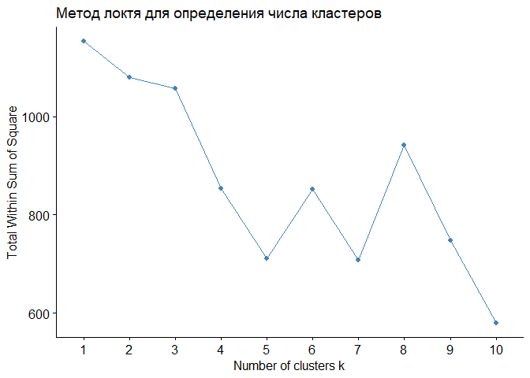

```r
fviz_nbclust(cluster_data, kmeans, method = "wss", k.max = 10) +
  labs(title = "Метод локтя для определения числа кластеров")
```

[figure not shown]

```r
set.seed(123)
k <- 4
kmeans_result <- kmeans(cluster_data, centers = k, nstart = 25)

client_network_filtered$cluster <- as.factor(kmeans_result$cluster)

cluster_profiles <- client_network_filtered %>%
  group_by(cluster) %>%
  summarise(across(starts_with("network_"), mean)) %>%
  pivot_longer(
    cols = starts_with("network_"),
    names_to = "network",
    names_prefix = "network_",
    values_to = "proportion"
  ) %>%
  group_by(cluster) %>%
  arrange(cluster, desc(proportion)) %>%
  slice_max(proportion, n = 5)

ggplot(cluster_profiles, aes(x = reorder(network, proportion), y = proportion, fill = cluster)) +
  geom_col() +
  facet_wrap(~ cluster, scales = "free_y") +
  coord_flip() +
  labs(
    title = "Топ-5 исследуемых сетей по кластерам",
    x = "Сеть",
    y = "Доля устройств в кластере, искавших сеть"
  ) +
  theme_minimal()
```

```r
clients_with_clusters <- clients_clean %>%
  inner_join(client_network_filtered %>% select(station_mac, cluster), by = "station_mac") %>%
  filter(!is.na(power) & power != -1)

clients_analysis <- clients_with_clusters %>%
  mutate(
    hour = hour(first_time_seen),
    time_bin = cut(hour, breaks = c(0, 6, 12, 18, 24),
                   labels = c("Ночь", "Утро", "День", "Вечер"))
  )

cluster_stability <- clients_analysis %>%
  group_by(cluster) %>%
  summarise(
    n_measurements = n(),
    mean_power = mean(power, na.rm = TRUE),
    median_power = median(power, na.rm = TRUE),
    sd_power = sd(power, na.rm = TRUE),
    cv_power = sd_power / abs(mean_power),
    min_power = min(power, na.rm = TRUE),
    max_power = max(power, na.rm = TRUE),
    range_power = max_power - min_power,
    iqr_power = IQR(power, na.rm = TRUE),
    q1_power = quantile(power, 0.25, na.rm = TRUE),
    q3_power = quantile(power, 0.75, na.rm = TRUE)
  ) %>%
  arrange(cv_power)

stability_ranking <- cluster_stability %>%
  select(cluster, mean_power, sd_power, cv_power, range_power, iqr_power) %>%
  mutate(
    stability_score = 1/cv_power,
    rank_stability = rank(cv_power)
  ) %>%
  arrange(rank_stability)

cat("РЕЙТИНГ СТАБИЛЬНОСТИ КЛАСТЕРОВ:\n")
```

```
РЕЙТИНГ СТАБИЛЬНОСТИ КЛАСТЕРОВ:
```

```r
print(stability_ranking)
```

```
# A tibble: 4 × 8
  cluster mean_power sd_power cv_power range_power iqr_power stability_score
  <fct>        <dbl>    <dbl>    <dbl>       <int>     <dbl>           <dbl>
1 3            -58.0     5.73   0.0987          36         8           10.1
2 4            -54.5     5.83   0.107           32         8            9.34
3 1            -61.5     7.33   0.119           66         6            8.39
4 2            -54.5     9.09   0.167           41         8            5.99
# ℹ 1 more variable: rank_stability <dbl>
```

```r
most_stable_cluster <- stability_ranking %>%
  filter(rank_stability == 1)

cat("\nСАМЫЙ СТАБИЛЬНЫЙ КЛАСТЕР:\n")
```

```
САМЫЙ СТАБИЛЬНЫЙ КЛАСТЕР:
```

```r
cat("Кластер:", most_stable_cluster$cluster, "\n")
```

```
Кластер: 3
```

```r
cat("Средний уровень сигнала:", round(most_stable_cluster$mean_power, 2), "dBm\n")
```

```
Средний уровень сигнала: -58.05 dBm
```

```r
cat("Стандартное отклонение:", round(most_stable_cluster$sd_power, 2), "dBm\n")
```

```
Стандартное отклонение: 5.73 dBm
```

```r
cat("Коэффициент вариации:", round(most_stable_cluster$cv_power, 3), "\n")
```

```
Коэффициент вариации: 0.099
```

```r
cat("Размах:", most_stable_cluster$range_power, "dBm\n")
```

```
Размах: 36 dBm
```

## Оценка результата

В результате лабораторной работы мы проанализировали трафик, используя dplyr и статистический анализ.

## Вывод

Таким образом, мы: - получили знания о методах исследования радиоэлектронной обстановки; - составили представление о механизмах работы Wi-Fi сетей на канальном и сетевом уровне модели OSI; - закрепили практические навыки использования языка программирования R для обработки данных; - закрепили знания основных функций обработки данных экосистемы tidyverse языка R.